# Exercice session 1: univariate extremes

Anna Kiriliouk and Johan Segers

UCLouvain, October 2024

## Exercise 1.

For this first exercise, you’ll need to install the `ismev` package first using `install.packages("ismev")`. Next, load the package and the data. The `data` vector contains daily maximal speeds of wind gusts, measured in kilometers per hour in Eindhoven (the Netherlands) during extended winter (October–March), from October 2001 up to and including March 2022.

```r
library(ismev)
load("Ex1uni.RData")
```

1. Use the following command to select monthly maxima. Then also select the yearly maxima (one for each extended winter season spanning from October to March).

```r
monthly <- as.vector(tapply(data, paste(times$year,times$mon), max))
yearly <- apply(matrix(monthly,ncol = 21, nrow = 6), 2, max)
```

2. Plot the two datasets. Do they look stationary?

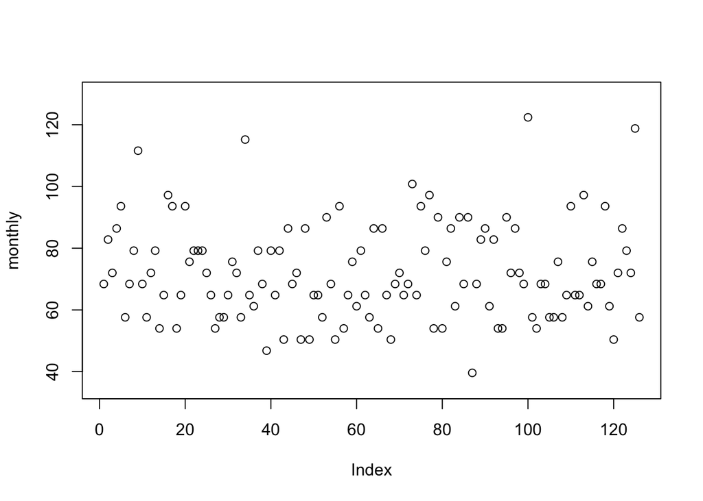

```r
plot(monthly, ylim = c(35,130))
```

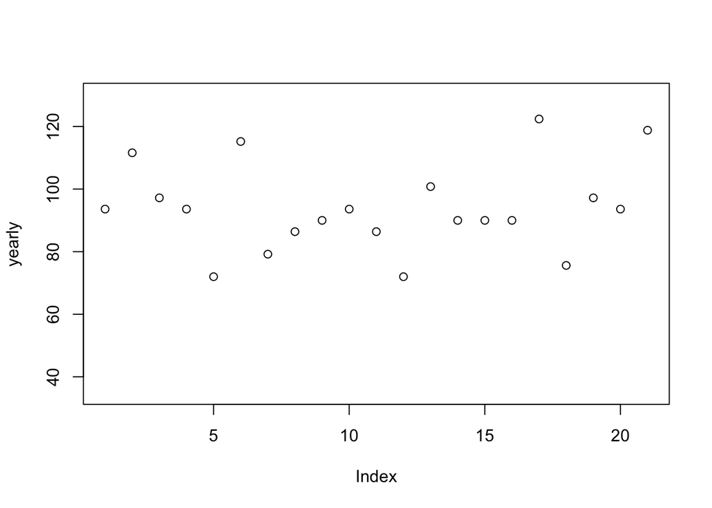

```r
plot(yearly, ylim = c(35,130))
```

3. Fit a GEV distribution to both the monthly and the yearly maxima and check the goodness-of-fit plots. You’ll need to use the functions `gev.fit`, and `gev.diag`. Which one of the two would you use?

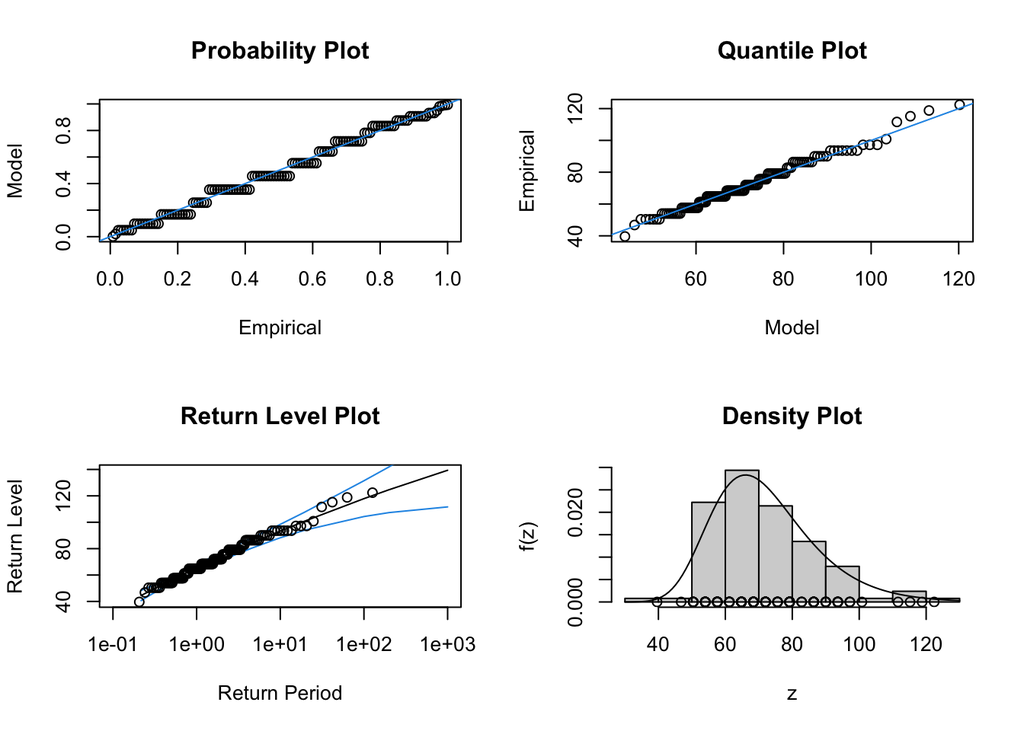

```r
gmonthly <- gev.fit(monthly, show = FALSE)
gyearly <- gev.fit(yearly, show = FALSE)
gev.diag(gmonthly)
```

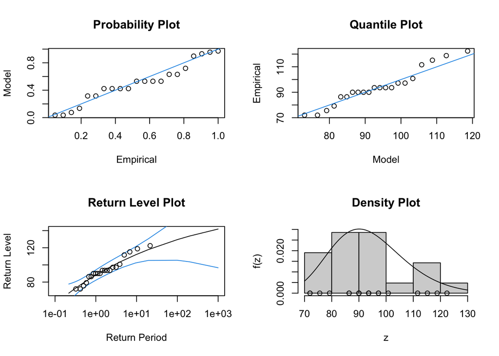

```r
gev.diag(gyearly)
```

```r
# I would go with the monthly maxima: the fit seems satisfactory and confidence intervals would be lower.
```

4. For the chosen data, give the GEV parameter estimates with 95 % confidence intervals. Is the data bounded-tailed, light-tailed or heavy-tailed?

```r
round(cbind(gmonthly$mle - 1.96*gmonthly$se, gmonthly$mle, gmonthly$mle + 1.96*gmonthly$se),2)
```

```
##       [,1]  [,2]  [,3]
## [1,] 62.71 65.26 67.82
## [2,] 11.18 13.01 14.84
## [3,] -0.18 -0.06  0.07
```

```r
round(cbind(gyearly$mle - 1.96*gyearly$se, gyearly$mle, gyearly$mle + 1.96*gyearly$se),2)
```

```
##       [,1]  [,2]  [,3]
## [1,] 82.17 88.15 94.14
## [2,]  8.06 12.32 16.58
## [3,] -0.49 -0.15  0.20
```

```r
# Light-tailed, in the Gumbel domain of attraction
```

5. Using the function `gum.fit`, estimate the parameters of a GEV distribution with $\xi = 0$. Decide whether such a model suffices based on a likelihood ratio test. *Reminder: if $L(\xi,\sigma,\mu)$ denotes the log-likelihood function, then $2 \left\{L(\xi,\sigma,\mu) - L(0,\sigma,\mu)\right\} \rightarrow \chi^2_1$.*

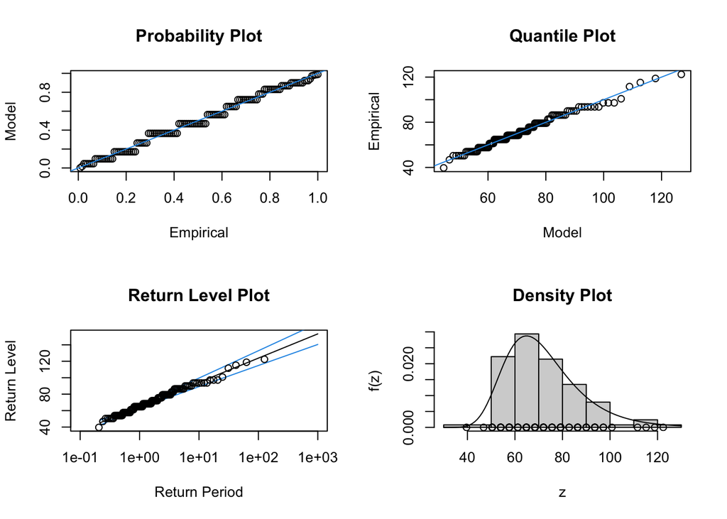

```r
gummonthly <- gum.fit(monthly, show = FALSE)
gumyearly <- gum.fit(yearly, show = FALSE)
gum.diag(gummonthly)
```

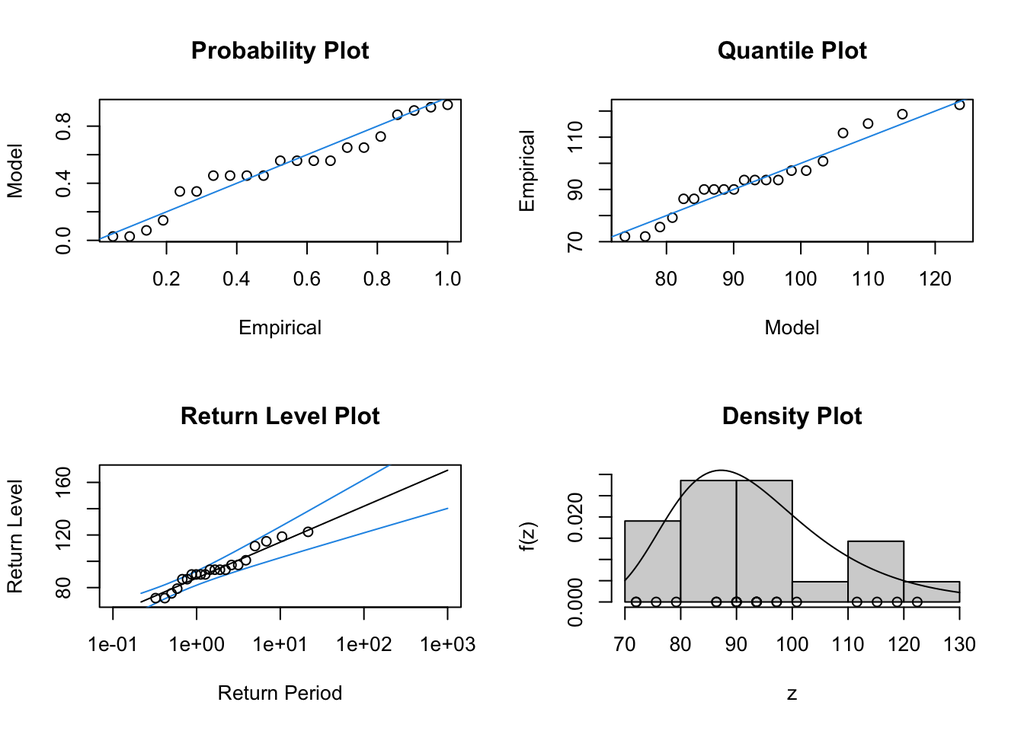

```r
gum.diag(gumyearly)
```

```r
(Dmonthly <- 2*(gummonthly$nllh - gmonthly$nllh))
```

```
## [1] 0.7391278
```

```r
(Dyearly <- 2*(gumyearly$nllh - gyearly$nllh))
```

```
## [1] 0.6194026
```

```r
qchisq(0.95, df = 1)
```

```
## [1] 3.841459
```

```r
retLevGum <- function(pars, cov, p){
  rl <- pars[1] - pars[2]*log(-log(1-p))
  grd <- c(1, -log(-log(1-p)))
  se <- sqrt(t(grd) %*% cov %*% grd)
  return(c(rl - 1.96*se, rl, rl + 1.96*se))
}
retLevGum(gummonthly$mle, gummonthly$cov, (1/10)/6) #convert to yearly
```

```
## [1] 109.0606 117.1775 125.2943
```

```r
retLevGum(gummonthly$mle, gummonthly$cov, (1/1000)/6) #convert to yearly
```

```
## [1] 160.3162 176.2404 192.1645
```

```r
retLevGum(gumyearly$mle, gumyearly$cov, 1/10)
```

```
## [1] 102.2971 113.9311 125.5652
```

```r
retLevGum(gumyearly$mle, gumyearly$cov, 1/1000)
```

```
## [1] 140.2321 169.2167 198.2013
```